# Trabajo Practico 2

# 6

```r
# primero corremos el modelo
modelo_q9 <- polr( as.factor(Q9) ~ age, data = entrenamiento)
summary(modelo_q9)
```

```
##
## Re-fitting to get Hessian
```

```
## Call:
## polr(formula = as.factor(Q9) ~ age, data = entrenamiento)
##
## Coefficients:
##         Value Std. Error t value
## age -0.007099    0.00226  -3.141
##
## Intercepts:
##     Value    Std. Error t value
## 0|1  -6.6623   0.2935   -22.6972
## 1|2  -0.7601   0.0573   -13.2754
## 2|3  -0.2368   0.0567    -4.1787
## 3|4   0.4850   0.0569     8.5211
## 4|5   1.2273   0.0587    20.9035
##
## Residual Deviance: 24614.02
## AIC: 24626.02
```

```r
#armo el dataframe de input
df_25 <- data.frame(age = c(25))
# hago una prediccion con el modelo
predicciones_q9 <- predict(modelo_q9, df_25, type = "p")

#Resultado del ejercicio, sumo la probabilidad para todas las opciones menores o iguales a 4
sum(predicciones_q9[0:5])
```

```
## [1] 0.8029444
```

# 7

Defino la funcion de perdida

```r
funcion_perdida <- function(predicciones, variable_respuesta){
  #predicciones espera un vector con los valores de y sombrero
  #variable respuesta espera un vector con los verdaderos valores de y
  diferencia_absoluta <- abs(predicciones - variable_respuesta)
  perdida <- sum(diferencia_absoluta)/length(variable_respuesta)
  return(perdida)
}
```

Evaluamos la funcion con los dos modelos creados hasta ahora.

```r
# Primero hago las predicciones
predicciones_q9 <- predict(modelo_q9, testeo)

#Aplico la funcion de perdida
funcion_perdida(as.numeric(predicciones_q28), testeo$Q28)
```

```
## [1] 1.760521
```

```r
funcion_perdida(as.numeric(predicciones_q9), testeo$Q9)
```

```
## [1] 1.386273
```

# 8

Primero armo y ajusto el modelo lineal

```r
# corro el modelo lineal
modelo_lineal_q28 <- lm(Q28 ~ age, data = entrenamiento)
summary(modelo_lineal_q28)
```

```
##
## Call:
## lm(formula = Q28 ~ age, data = entrenamiento)
##
## Residuals:
##     Min      1Q  Median      3Q     Max
## -2.1351 -1.5044  0.0369  1.1516  3.5563
##
## Coefficients:
##              Estimate Std. Error t value Pr(>|t|)
## (Intercept)  3.507814   0.046111   76.07   <2e-16 ***
## age         -0.028669   0.001857  -15.44   <2e-16 ***
## ---
## Signif. codes:  0 '***' 0.001 '**' 0.01 '*' 0.05 '.' 0.1 ' ' 1
##
## Residual standard error: 1.494 on 7970 degrees of freedom
## Multiple R-squared:  0.02903,    Adjusted R-squared:  0.0289
## F-statistic: 238.3 on 1 and 7970 DF,  p-value: < 2.2e-16
```

En segundo lugar, genero una funcion que tome las predicciones del modelo y las acote a los valores ordinales que puede tomar la variable de respuesta.

```r
pred_linear_fun <- function(predicciones){
  predicciones_redondeadas <- round(predicciones)
  #Redondeo a 1 si da menor que 1 y a 5 si da mayor que 5
  predicciones_ajustadas <- sapply(
    predicciones_redondeadas,
     function(x) ifelse(x < 1, 1,
                        ifelse(x > 5, 5, x))
     )
  return(predicciones_ajustadas)
}
```

Implemento la funcion con las predicciones del modelo lineal

```r
predicciones_linear_q28 <- pred_linear_fun(predict(modelo_lineal_q28, testeo))
```

# 9

```r
# veo los resultados de las funciones de perdidas anterior
perdida_lineal_q28 <- funcion_perdida(
  predicciones_linear_q28,
  testeo$Q28
)
perdida_ordinal_q28 <- funcion_perdida(
  as.numeric(predicciones_q28),
  testeo$Q28
)

c(
  'Perdida Lineal' = perdida_lineal_q28,
  'Perdida Ordinal' = perdida_ordinal_q28
)
```

```
##  Perdida Lineal Perdida Ordinal
##        1.298597        1.760521
```

Parece ser que el modelo lineal presenta una menor funcion de perdida que el modelo de regresion ordinal.

# 10

El modelo de regresion ordinal puede utilizar diferentes funciones de link por lo que vamos implementar una funcion que pruebe todas las posbiles funciones de link para modelo.

```r
library(purrr)

varios_ordinales_fun <- function(formula){
  # corro varios modelos cada uno con su link function
link_functions <- c("logistic", "probit", "loglog", "cauchit")

varios_modelos <- link_functions %>%
  map(~ polr(as.formula(formula), data = entrenamiento, method = .x)) %>%
  map(~ funcion_perdida(
    as.numeric(predict(.x, testeo)),
    testeo$Q28)
    )
  return(unlist(varios_modelos))
}

## Agregamos al modelo predictores que nos parecen que tienen sentido

# es posible que la edad pueda predecir si llevan una manta en la casa
modelo_edad <- varios_ordinales_fun('as.factor(Q28) ~ age')

# algunas religiones podrian utilizar mantas como parte de su vestimenta
modelo_edad_y_religion <- varios_ordinales_fun('as.factor(Q28) ~ age + religion')

# es posible que las personas que puntuan alto en "soy el mas feliz cuando estoy en la cama" tenga una relacion con la pregunta Q28
modelo_edad_religion_y_q10 <- varios_ordinales_fun('as.factor(Q28) ~ age + religion + Q10')

# Puede ser que edad y religion presenten una interaccion al predecir Q28.
# Por ejemplo, quizas en algunas religiones personas mas grandes puntuen alto en Q28, no asi las personas mas jovenes.
modelo_religion_edad_q10_interaccion <- varios_ordinales_fun('as.factor(Q28) ~ age + religion + age:religion + Q10')

# evaluamos con un ANOVA si se justifica agregar un predictor al modelo
anova(
  polr(as.factor(Q28) ~ 1, data = entrenamiento),
  polr(as.factor(Q28) ~ age, data = entrenamiento),
  polr(as.factor(Q28) ~ age + religion, data = entrenamiento),
  polr(as.factor(Q28) ~ age + religion + Q10, data = entrenamiento),
  polr(as.factor(Q28) ~ age + religion + age:religion + Q10, data = entrenamiento)
)
```

```
## Likelihood ratio tests of ordinal regression models
##
## Response: as.factor(Q28)
##                                 Model Resid. df Resid. Dev   Test    Df
## 1                                   1      7968   25153.75
## 2                                 age      7967   24908.48 1 vs 2     1
## 3                      age + religion      7966   24891.16 2 vs 3     1
## 4                age + religion + Q10      7965   24534.16 3 vs 4     1
## 5 age + religion + age:religion + Q10      7964   24531.84 4 vs 5     1
##     LR stat.      Pr(Chi)
## 1
## 2 245.267515 0.000000e+00
## 3  17.325986 3.148518e-05
## 4 356.998941 0.000000e+00
## 5   2.322076 1.275497e-01
```

```r
# evaluamos la funcion de perdida y mostramos los resultados
data.frame(
 perdida = c(modelo_edad, modelo_edad_y_religion, modelo_edad_religion_y_q10, modelo_religion_edad_q10_interaccion),
 modelo = rep(c('edad','edad y religion', 'edad, religion y q10', 'religion, edad, q10 e interaccion'), each = 4)
) %>% group_by(modelo) %>% summarize(min(perdida))
```

```
## # A tibble: 4 × 2
##   modelo                            `min(perdida)`
##   <chr>                                      <dbl>
## 1 edad                                        1.76
## 2 edad y religion                             1.71
## 3 edad, religion y q10                        1.54
## 4 religion, edad, q10 e interaccion           1.54
```

# 11

Exploro algunas variables que nos parecen interesantes como posibles predictores de titulo universitario

```r
# genero
table(data$gender)
```

```
##
##    0    1    2    3
##  139 4129 4906  826
```

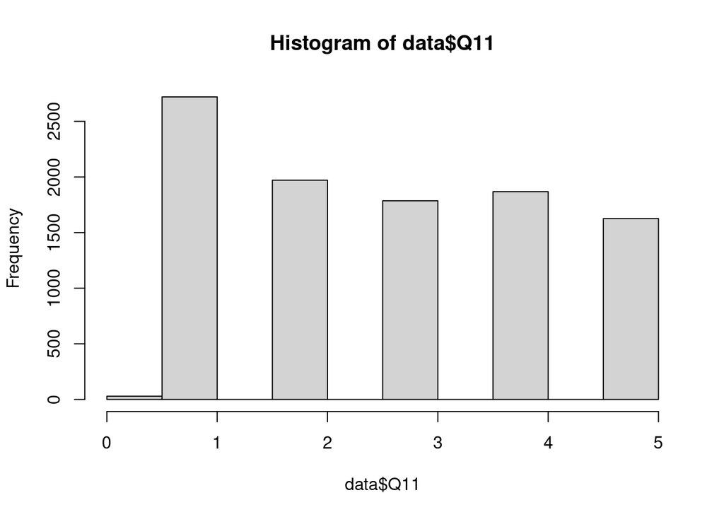

```r
# es raro que aparezca el 0, ya que no esta en el codebook.txt,
# lo voy a sacar
entrenamiento <- entrenamiento %>% filter(gender != 0)
testeo <- testeo %>% filter(gender != 0)

# Q11   I did not work very hard in school.
hist(data$Q11)
```

```r
table(data$Q11)
```

```
##
##    0    1    2    3    4    5
##   29 2720 1971 1786 1868 1626
```

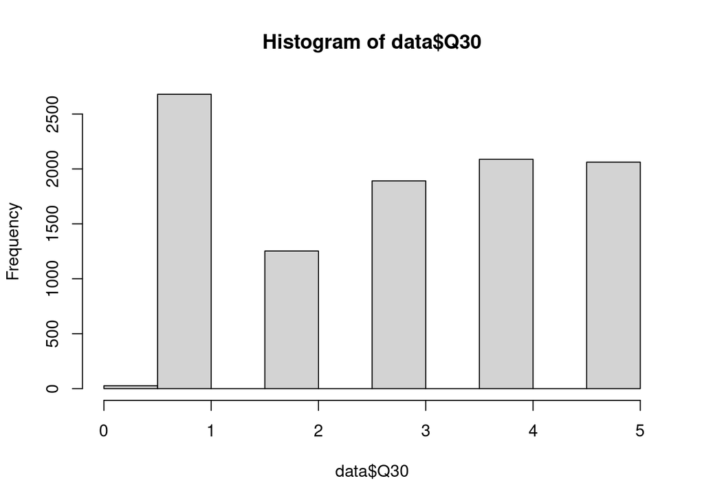

```r
# saco a los datos con respuesta 0
entrenamiento <- entrenamiento %>% filter(Q11 != 0)
testeo <- testeo %>% filter(Q11 != 0)

# Q30   I think horoscopes are fun.
hist(data$Q30)
```

```r
table(data$Q30)
```

```
##
##    0    1    2    3    4    5
##   26 2680 1253 1891 2088 2062
```

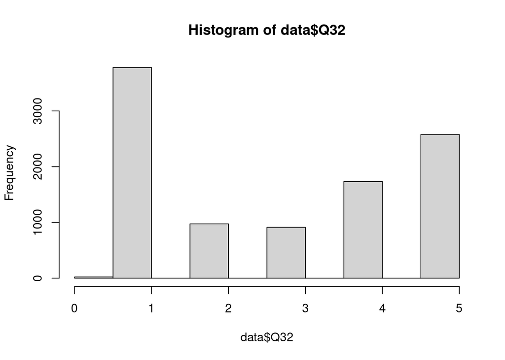

```r
# saco a los datos con respuesta 0
entrenamiento <- entrenamiento %>% filter(Q30 != 0)
testeo <- testeo %>% filter(Q30 != 0)

# Q32   I have thought about becoming a vegetarian.
hist(data$Q32)
```

```r
table(data$Q32)
```

```
##
##    0    1    2    3    4    5
##   21 3780  974  912 1735 2578
```

```r
# saco a los datos con respuesta 0
entrenamiento <- entrenamiento %>% filter(Q32 != 0)
testeo <- testeo %>% filter(Q32 != 0)
```

Preparo el df para correr el modelo. En la pregunta “How much education have you completed?”:

No tiene titulo universitario = 1=Less than high school, 2=High school

Tiene titulo universitario = 3=University degree, 4=Graduate degree

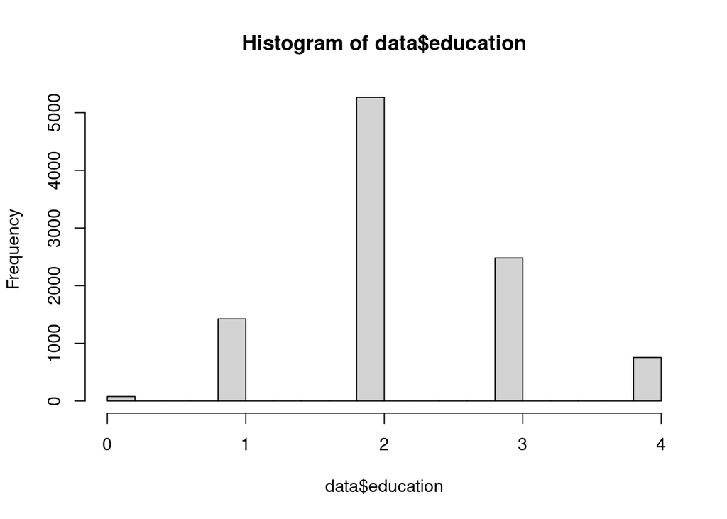

```r
# exploro la variable de educacion
hist(data$education)
```

```r
table(data$education)
```

```
##
##    0    1    2    3    4
##   77 1422 5267 2480  754
```

```r
# saco a los datos con respuesta 0
entrenamiento <- entrenamiento %>% filter(education != 0)
testeo <- testeo %>% filter(education != 0)

# binarizo la variable de respuesta, siendo 0: no tienen titulo universitario, y 1: tiene titulo universitario
entrenamiento$education_universitaria<- ifelse(entrenamiento$education == 1 | entrenamiento$education == 2, 0, 1)
testeo$education_universitaria<- ifelse(testeo$education == 1 | testeo$education == 2, 0, 1)
```

Corro el modelo y calculo el error segun la exactitud

```r
mod_log <- glm(education_universitaria ~
                  gender +
                  Q11 +
                  Q30+
                  Q32+
                  age,
           family=binomial(link="logit"),
           data = entrenamiento)

summary(mod_log)
```

```
##
## Call:
## glm(formula = education_universitaria ~ gender + Q11 + Q30 +
##     Q32 + age, family = binomial(link = "logit"), data = entrenamiento)
##
## Deviance Residuals:
##     Min       1Q   Median       3Q      Max
## -3.0923  -0.7517  -0.6017   0.9870   2.1700
##
## Coefficients:
##              Estimate Std. Error z value Pr(>|z|)
## (Intercept) -2.864980   0.140383 -20.408  < 2e-16 ***
## gender      -0.073557   0.047133  -1.561    0.119
## Q11         -0.188976   0.019353  -9.765  < 2e-16 ***
## Q30         -0.095464   0.018996  -5.025 5.02e-07 ***
## Q32          0.095917   0.016664   5.756 8.61e-09 ***
## age          0.118242   0.003838  30.808  < 2e-16 ***
## ---
## Signif. codes:  0 '***' 0.001 '**' 0.01 '*' 0.05 '.' 0.1 ' ' 1
##
## (Dispersion parameter for binomial family taken to be 1)
##
##     Null deviance: 9783.8  on 7748  degrees of freedom
## Residual deviance: 8249.8  on 7743  degrees of freedom
## AIC: 8261.8
##
## Number of Fisher Scoring iterations: 4
```

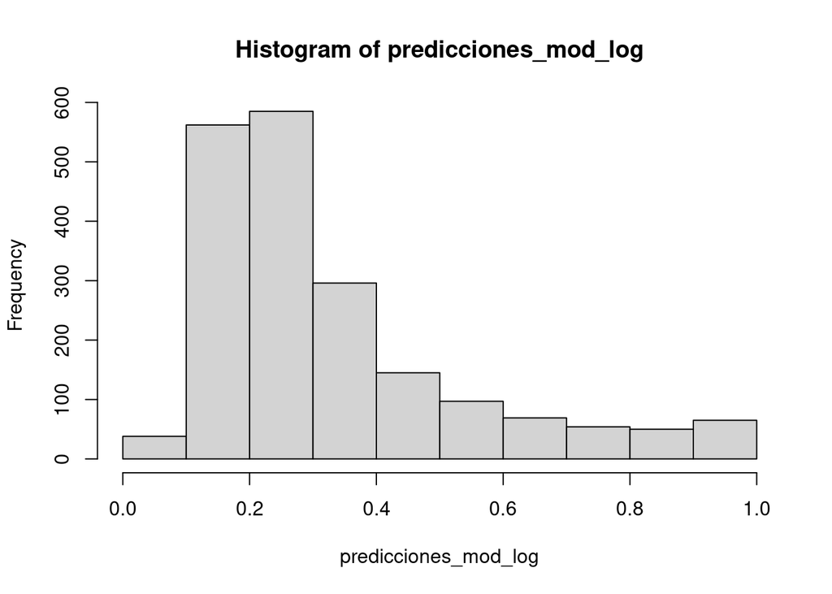

```r
predicciones_mod_log <- predict(mod_log, testeo, type="response")
hist(predicciones_mod_log)
```

```r
predicted.classes <- ifelse(predicciones_mod_log > 0.5, 1, 0)

# veo exactitud
mean(predicted.classes == testeo$education_universitaria)
```

```
## [1] 0.7251402
```

# 12

En primer lugar generamos varias muestras aleatorias de nuestro dataframe, con distinto n pero sin repeticion. Para eso armamos una distribucion uniforme entre los dos rangos de valores que consideramos apropiados. Vamos a usar 1000 muestras a partir de un rango de entre 50 y 5000 datos.

Armamos para esto una funcion la cual, en cada iteracion saca una muestra de la distribucion uniforme que definimos y seleciona una muestra aleatoria de nuestros datos con ese tamaño muestral.

```r
random_sampling_fun <- function(){
  random_n <- runif(1,50,5000)
  datos_sampleados <- entrenamiento %>% dplyr::slice_sample(. ,n = random_n)
  return(datos_sampleados)
}
```

Generamos otra funcion que va a utilizar los datos creados por la funcion `random_sampling_fun` y los va a usar para ajustar un modelo de regresion logistica calculando la exactitud. La exactitud siempre se calcula sobre el conjunto de testeo que tiene un tamaño fijo. De esta manera la funcion otorga un vector de dos valores, uno indicando la cantidad de datos utilizados y otro indicando el valor de exactitud obtenido.

```r
random_fit_predict <- function(){
  datos_muestrales <- random_sampling_fun()
  n_muestral <- nrow(datos_muestrales)
  #Aca va el modelo de regresion logistica
  modelo <- glm(education_universitaria ~
                  gender +
                  Q11 +
                  Q30+
                  Q32+
                  age,
           family=binomial(link="logit"),
           data = datos_muestrales)

  #Aca va la funcion de calculo de exactitud
  exactitud <- mean(
    ifelse(predict(modelo, testeo, type="response") > 0.5, 1, 0) == testeo$education_universitaria
    )
  resultado <- c(n_muestral, exactitud)
  return(resultado)
}
```

Una vez definidas ambas funciones las integramos en un loop que corra 1000 veces para obtener 1000 pares de combinaciones de tamaño muestral y exactitud.

```r
multiple_log <- replicate(1000, random_fit_predict())
```

Posteriormente creamos un dataframe de los resultados usando la matriz transpuesta.

```r
multiple_log_df <- as.data.frame(
  t(multiple_log)
)
colnames(multiple_log_df) <- c('N', 'Exactitud')
```

Graficamos el resultado de la exactitud en funcion del N y le aplicamos un ajuste local para tratar de ver patrones.

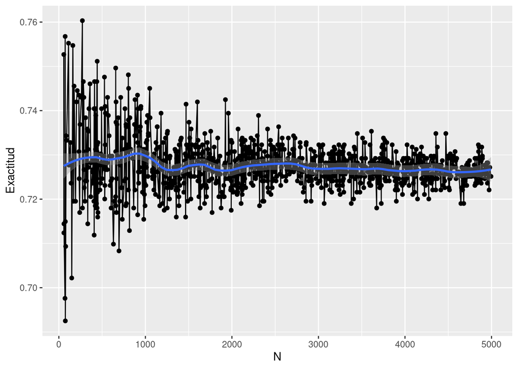

```r
ggplot(data = multiple_log_df, aes(x = N, y = Exactitud)) +
  geom_point() + geom_line() + geom_smooth(span = 0.2, method = 'loess')
```

Pareceria que la exactitud sube con el N unicamente para valores pequeños, menores a 200 aproximadamente, pero despues converge hacia un determinado valor perdiendo variabilidad con valores de tamaño de muestra mas grandes.

```r
library(betareg)
beta_unif <- betareg::betareg(Exactitud ~ N, data = multiple_log_df)
summary(beta_unif)
```

```
##
## Call:
## betareg::betareg(formula = Exactitud ~ N, data = multiple_log_df)
##
## Standardized weighted residuals 2:
##     Min      1Q  Median      3Q     Max
## -6.0665 -0.4934 -0.0450  0.4359  5.6156
##
## Coefficients (mean model with logit link):
##               Estimate Std. Error z value Pr(>|z|)
## (Intercept)  9.902e-01  1.932e-03 512.525  < 2e-16 ***
## N           -3.332e-06  6.575e-07  -5.067 4.03e-07 ***
##
## Phi coefficients (precision model with identity link):
##       Estimate Std. Error z value Pr(>|z|)
## (phi)   5841.0      261.2   22.36   <2e-16 ***
## ---
## Signif. codes:  0 '***' 0.001 '**' 0.01 '*' 0.05 '.' 0.1 ' ' 1
##
## Type of estimator: ML (maximum likelihood)
## Log-likelihood:  3727 on 3 Df
## Pseudo R-squared: 0.02497
## Number of iterations: 58 (BFGS) + 7 (Fisher scoring)
```

La regresion beta nos arroja un coeficiente negativo para la asociacion el N.

Podriamos probar ahora con usar una grilla de valores de tamaño de muestra que se vaya incrementando desde 50 a 5000, con una longitud total de 1000 valores como en el caso anterior.

```r
grilla_n <- seq(50,5000, length.out = 1000)
```

El problema es que la funcion `random_sampling_fun` tiene ya establecido usar `runif` por lo que habria que modificarla para poder usar la funcion `random_fit_predict` con la grilla. Vamos a modificarla de manera que tome como argumento una funcion o valor numerico que defina el tamaño muestral. Tambien modificamos la funcion `random_fit_predict` para que pueda tomar el argumento que se le va a suministrar a `random_sampling_fun`.

```r
random_sampling_fun <- function(random_fun){
  random_n <- random_fun
  datos_sampleados <- entrenamiento %>% dplyr::slice_sample(. ,n = random_n)
  return(datos_sampleados)
}

random_fit_predict <- function(random_fun){
  datos_muestrales <- random_sampling_fun(random_fun)
  n_muestral <- nrow(datos_muestrales)
  #Aca va el modelo de regresion logistica
  modelo <- glm(education_universitaria ~
                  gender +
                  Q11 +
                  Q30+
                  Q32+
                  age,
           family=binomial(link="logit"),
           data = datos_muestrales)

  #Aca va la funcion de calculo de exactitud
  exactitud <- mean(
    ifelse(predict(modelo, testeo, type="response") > 0.5, 1, 0) == testeo$education_universitaria
    )
  resultado <- c(n_muestral, exactitud)
  return(resultado)
}
```

Implementamos ahora la funcion con la grilla

```r
multiple_log_grilla <-  sapply(grilla_n, random_fit_predict)
```

Igual que hicimos en el caso anterior armamos un dataframe con la matriz transpuesta.

```r
multiple_log_grilla_df <- as.data.frame(t(multiple_log_grilla))
colnames(multiple_log_grilla_df) <- c('N', 'Exactitud')
```

Graficamos la exactitud en funcion del N.

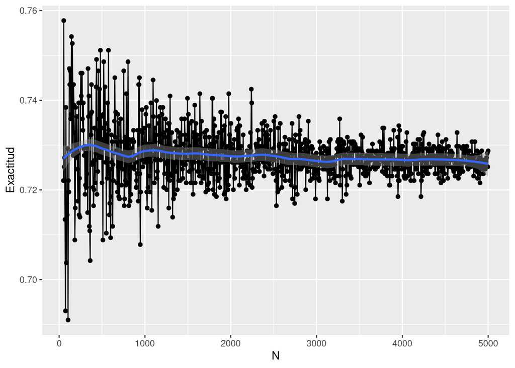

```r
ggplot(data = multiple_log_grilla_df, aes(x = N, y = Exactitud)) +
  geom_point() + geom_line() + geom_smooth(span = 0.2, method = 'loess')
```

En este caso no pareceria haber una pendiente negativa evidente como en el anterior pero vemos que el tamaño de la muestra no mejora la exactitud salvo con los valores mas bajos. Ajustamos entonces la regresion beta.

```r
beta_grilla <- betareg::betareg(Exactitud ~ N, data = multiple_log_grilla_df)
summary(beta_grilla)
```

```
##
## Call:
## betareg::betareg(formula = Exactitud ~ N, data = multiple_log_grilla_df)
##
## Standardized weighted residuals 2:
##     Min      1Q  Median      3Q     Max
## -5.9831 -0.4738 -0.0125  0.4376  4.8686
##
## Coefficients (mean model with logit link):
##               Estimate Std. Error z value Pr(>|z|)
## (Intercept)  9.899e-01  1.986e-03 498.421  < 2e-16 ***
## N           -3.136e-06  6.839e-07  -4.586 4.52e-06 ***
##
## Phi coefficients (precision model with identity link):
##       Estimate Std. Error z value Pr(>|z|)
## (phi)   5270.4      235.7   22.36   <2e-16 ***
## ---
## Signif. codes:  0 '***' 0.001 '**' 0.01 '*' 0.05 '.' 0.1 ' ' 1
##
## Type of estimator: ML (maximum likelihood)
## Log-likelihood:  3675 on 3 Df
## Pseudo R-squared: 0.02057
## Number of iterations: 43 (BFGS) + 4 (Fisher scoring)
```

El coeficiente igual sigue siendo negativo.

Podemos repetir el procedimiento de usar una distribucion uniforme sobre el tamaño muestral pero esta vez teniendo una cota superior mucho mas chica.

```r
multiple_small_n <- replicate(1000,
          random_fit_predict(runif(1,30,200))
          )
multiple_small_n_df <- as.data.frame(t(multiple_small_n))
colnames(multiple_small_n_df) <- c('N', 'Exactitud')
```

Graficamos

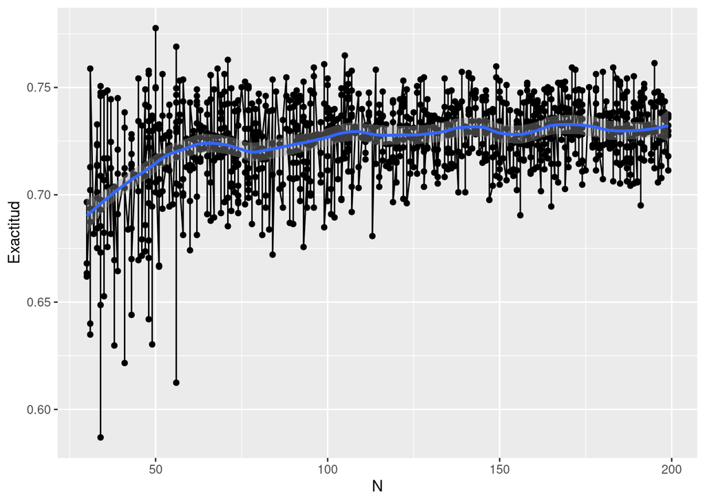

```r
ggplot(data = multiple_small_n_df, aes(x = N, y = Exactitud)) +
  geom_point() + geom_line() + geom_smooth(span = 0.2, method = 'loess')
```

Aca pareceria haber una relacion positiva entre el tamaño muestral y la exactitud.

```r
beta_small_n <- betareg(Exactitud ~ N, data = multiple_small_n_df)
summary(beta_small_n)
```

```
##
## Call:
## betareg(formula = Exactitud ~ N, data = multiple_small_n_df)
##
## Standardized weighted residuals 2:
##     Min      1Q  Median      3Q     Max
## -5.8690 -0.5801  0.0624  0.6385  3.3923
##
## Coefficients (mean model with logit link):
##              Estimate Std. Error z value Pr(>|z|)
## (Intercept) 8.899e-01  7.813e-03  113.91   <2e-16 ***
## N           6.723e-04  6.194e-05   10.85   <2e-16 ***
##
## Phi coefficients (precision model with identity link):
##       Estimate Std. Error z value Pr(>|z|)
## (phi)    530.3       23.7   22.38   <2e-16 ***
## ---
## Signif. codes:  0 '***' 0.001 '**' 0.01 '*' 0.05 '.' 0.1 ' ' 1
##
## Type of estimator: ML (maximum likelihood)
## Log-likelihood:  2526 on 3 Df
## Pseudo R-squared: 0.1058
## Number of iterations: 18 (BFGS) + 2 (Fisher scoring)
```

```r
predicciones_beta_df <- data.frame(
  Exactitud = predict(beta_small_n, data.frame(N = seq(50,5000, 50))),
  N = seq(50, 5000, 50)
)
```

Graficamos comparando con los anteriores resultados.

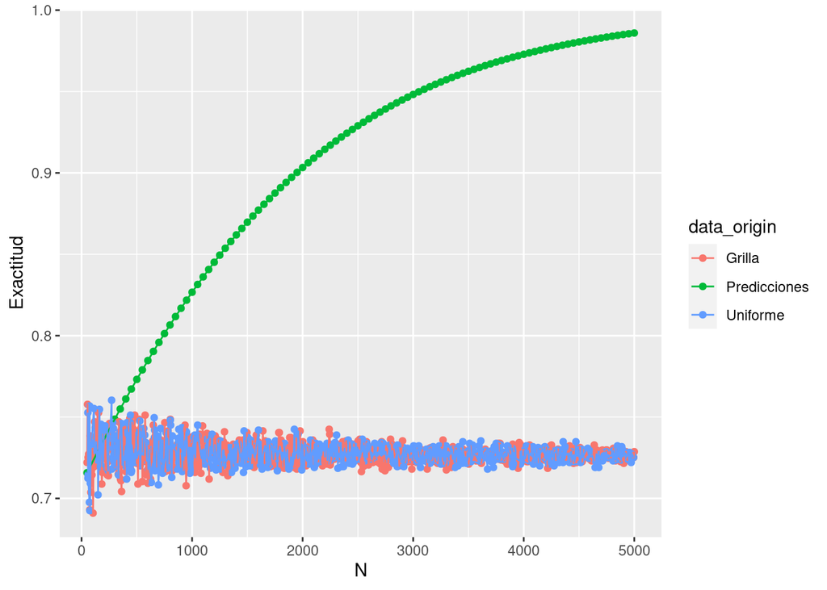

```r
rbind(predicciones_beta_df, multiple_log_grilla_df, multiple_log_df) %>%
  mutate(
    data_origin = rep(
      c('Predicciones', 'Grilla', 'Uniforme'),
      c(nrow(predicciones_beta_df), nrow(multiple_log_grilla_df), nrow(multiple_log_df))
    )
  ) %>%
  ggplot(aes(x = N, y = Exactitud, color = data_origin)) +
  geom_point() + geom_line()
```

El modelo predice bien dentro del rango de datos que usamos para la regresion beta es decir tamaños muestrales hasta 200 pero despues generaliza muy mal a medida que el n aumenta.

```r
predicciones_beta_df$N[which.min(abs(0.9 - predicciones_beta_df$Exactitud))]
```

```
## [1] 1950
```

Podemos comprobar el modelo que armamos para una exactitud de 0.9 pero vemos que esa exactitud luego no se cumple cuando contamos con esa cantidad de datos.